# Is Chicago Breathing Equally? A Spatial Analysis of PM2.5 and Respiratory Risk

Lizbeth Macias

2026-02-22

## **Introduction**

Air pollution, especially fine particulate matter (PM2.5), is a major public health issue across the United States, and Chicago is one example of how this problem plays out at the city level. While national and regional air quality averages show improvement over time, they often hide important local differences in exposure. Citywide averages can hide the fact that some neighborhoods continue to experience much higher levels of pollution than others. To better understand environmental resilience and inequality in exposure, it is important to look at air quality at the neighborhood level instead of only relying on city-level data.

## *Methods Overview*

Data cleaning involved selecting relevant variables, renaming columns, converting date strings into proper datetime formats, and removing rows with missing PM2.5 or AQI values. Duplicate sensor locations were filtered out so each sensor contributed one unique spatial point. Sensors were assigned to four regions (Northwest, Northeast, Southwest, Southeast) based on their latitude and longitude relative to downtown Chicago.

Analyses included violin and ridgeline distributions, boxplots, scatterplots, and a linear regression model examining the relationship between NO₂ and PM2.5. These visualizations were used to evaluate spatial and temporal inequality in Chicago’s air quality.

## **Research Objectives**

The main goal of this project is to see how particulate air pollution changes over time and across different neighborhoods in Chicago using the Open Air Chicago Network data set. I focused on three main variables: pm25_mass, pm25_aqi, and no2, and looked at how they vary by day and by sensor. By using the dates to follow day‑to‑day changes and sensor_name, latitude, and longitude to compare and map locations, this project aims to find neighborhoods with consistently higher pollution, possible inequalities in exposure, and point out areas that seem more environmentally resilient.

**Data features**

For this project, I used the daily Open Air Chicago Aggregation File, which reports 24 hour mean air-quality for each sensor site in the city. The key variables I analyzed were:

- startofperiod, which gives the date of each 24‑hour period and is used to track how air quality changes over time.
- sensor_name, which identifies each monitoring location and lets me compare conditions across different neighborhoods.
- pm25ConcMass24HourMean.value, the daily mean PM2.5 concentration, which is directly linked to respiratory health risks.
- pm25ConcMass24HourMeanUsEpaAqi.value, the corresponding U.S. EPA AQI value based on PM2.5, used to classify overall air‑quality levels.
- no2Conc24HourMean.value, the daily mean nitrogen dioxide concentration, which provides additional context about traffic‑related pollution in urban areas.

```r
#Note: Uploaded csv file to new rmd file and created new chunk line to indicate to r that this is the file/data I want to appear here.

data <- read.csv("~/R/Open_Air_Chicago_Day_Aggregations_20260212(1) (1).csv")

install.packages("readr")
library(readr)
```

```r
# load library
air_data <- read_csv("~/R/Open_Air_Chicago_Day_Aggregations_20260212(1) (1).csv")
#Note: Created this chunk line to double check and confirm I loaded the correct data.
#Note: I am able to visibly see that there are 45,612 rows and 46 columns, which tells me this was a success.
library(dplyr)
glimpse(air_data)
```

```
## Rows: 45,612
## Columns: 46
## $ datasourceid                          <chr> "DIQKT3554", "DLDVK7370", "DQIUL…
## $ outputfrequency                       <chr> "day", "day", "day", "day", "day…
## $ startofperiod                         <chr> "10/21/2025 12:00:00 AM", "12/24…
## $ sensor_name                           <chr> "Lincoln Park 1", "South Chicago…
## $ atmPressure24HourMean.raw             <dbl> NA, NA, NA, NA, NA, NA, NA, NA, …
## $ atmPressure24HourMean.value           <dbl> NA, NA, NA, NA, NA, NA, NA, NA, …
## $ bcAllSources24HourMean.raw            <lgl> NA, NA, NA, NA, NA, NA, NA, NA, …
## $ bcAllSources24HourMean.value          <lgl> NA, NA, NA, NA, NA, NA, NA, NA, …
## $ bcBiomass24HourMean.raw               <lgl> NA, NA, NA, NA, NA, NA, NA, NA, …
## $ bcBiomass24HourMean.value             <lgl> NA, NA, NA, NA, NA, NA, NA, NA, …
## $ bcFossilFuel24HourMean.raw            <lgl> NA, NA, NA, NA, NA, NA, NA, NA, …
## $ bcFossilFuel24HourMean.value          <lgl> NA, NA, NA, NA, NA, NA, NA, NA, …
## $ bcSpectralB24HourMean.raw             <lgl> NA, NA, NA, NA, NA, NA, NA, NA, …
```

[output cut: 33 more lines]

```r
#Note: Downloaded Cook County census tract boundaries as an sf object
chicago_tracts <- tracts(
  state = "IL",
  county = "Cook",
  year = 2022,
  class = "sf"
)

#Note: Ensured that coordinate system matches sensor data (WGS84)
chicago_tracts <- st_transform(chicago_tracts, 4326)
```

```r
#Note: This code is filtering the air quality data set using tidyverse library.
#Note: (select) Subsets the data to keep only specific columns like date, sensor name, pollutants (PM2.5, NO2), and location.
#Note: (rename) changes the long name into a simpler, more readable one.
#Note: (mutate) this uses the lubridate package to convert the date column from a text string into a proper Date-Time format.
#Note: (filter) This removes any rows with missing values (NA) into PM2.5 mass or AQI columns to ensure data quality.

# Select relevant air pollution and location variables
filtered_data <- air_data %>%
  select(
    startofperiod,
    sensor_name,
    pm2_5ConcMass24HourMean.value,
    pm2_5ConcMass24HourMeanUsEpaAqi.value,
    no2Conc24HourMean.value,
    latitude,
    longitude
  ) %>%
#Note: Renamed the variables for cleaner usage
  rename(
    date = startofperiod,
    pm25_mass = pm2_5ConcMass24HourMean.value,
    pm25_aqi = pm2_5ConcMass24HourMeanUsEpaAqi.value,
    no2 = no2Conc24HourMean.value
  ) %>%
  # Convert date column to proper datetime format
  mutate(date = mdy_hms(date)) %>%
  # Remove rows with missing pollution values
  filter(!is.na(pm25_mass),
         !is.na(pm25_aqi))

#Note: Data Check
#Note: Confirming that only the intended variables were kept and properly formatted.
glimpse(filtered_data)
```

```
## Rows: 45,352
## Columns: 7
## $ date        <dttm> 2025-10-21, 2025-12-24, 2025-11-13, 2025-10-22, 2025-11-2…
## $ sensor_name <chr> "Lincoln Park 1", "South Chicago 2", "South Shore 1", "O'H…
## $ pm25_mass   <dbl> 4.39, 17.64, 7.48, 3.38, 23.53, 10.93, 11.88, 3.88, 6.56, …
## $ pm25_aqi    <dbl> 24, 67, 41, 18, 78, 54, 56, 21, 36, 28, 29, 69, 23, 23, 60…
## $ no2         <dbl> 13.29, 14.54, NA, 9.68, 22.57, 13.37, NA, NA, NA, NA, NA, …
## $ latitude    <dbl> 41.92155, 41.75137, 41.76413, 41.97628, 41.96518, 41.81509…
## $ longitude   <dbl> -87.65449, -87.55254, -87.58575, -87.85276, -87.87625, -87…
```

```r
summary(filtered_data[, c("pm25_mass", "pm25_aqi", "no2")])
```

```
##    pm25_mass        pm25_aqi           no2
##  Min.   : 1.69   Min.   :  9.00   Min.   : 4.68
##  1st Qu.: 6.40   1st Qu.: 36.00   1st Qu.:12.20
##  Median : 9.37   Median : 51.00   Median :14.42
##  Mean   :10.56   Mean   : 48.34   Mean   :14.96
##  3rd Qu.:13.38   3rd Qu.: 59.00   3rd Qu.:17.07
##  Max.   :55.21   Max.   :150.00   Max.   :36.72
##                                   NA's   :19817
```

```r
#Note: Classified each sensor into one of four Chicago quadrants (NorthEast, NorthWest, SouthEast, SouthWest)
filtered_data <- filtered_data %>%
  mutate(
    region = case_when(
      latitude >= 41.8781 & longitude >= -87.6298 ~ "NorthEast",
      latitude >= 41.8781 & longitude < -87.6298  ~ "NorthWest",
      latitude < 41.8781 & longitude >= -87.6298  ~ "SouthEast",
      latitude < 41.8781 & longitude < -87.6298   ~ "SouthWest",
      TRUE ~ NA_character_
    )
  )
```

```r
#Note: Separated the data set into individual years for comparison
data_2024 <- filtered_data %>%
  filter(year(date) == 2024)

data_2025 <- filtered_data %>%
  filter(year(date) == 2025)
```

```r
#Note: This code chunks allows one unique location per sensor to avoid repeated daily records
clean_2024 <- data_2024 %>%
  select(sensor_name, latitude, longitude) %>%
  filter(!is.na(latitude), !is.na(longitude)) %>%
  distinct()

clean_2025 <- data_2025 %>%
  select(sensor_name, latitude, longitude) %>%
  filter(!is.na(latitude), !is.na(longitude)) %>%
  distinct()
```

```r
#Note: Converts the sensor coordinate data into spatial (sf) objects
sf_2024 <- st_as_sf(clean_2024,
                    coords = c("longitude", "latitude"),
                    crs = 4326)
sf_2025 <- st_as_sf(clean_2025,
                    coords = c("longitude", "latitude"),
                    crs = 4326)
```

```r
#Note: This attaches census tract information to each sensor point
join_2024 <- st_join(sf_2024, chicago_tracts)
join_2025 <- st_join(sf_2025, chicago_tracts)
```

```r
#Note: This code chunk counts how many sensors fall within each census tract
counts_2024 <- join_2024 %>%
  group_by(GEOID) %>%
  summarise(sensor_count = n(), .groups = "drop") %>%
  st_drop_geometry()

counts_2025 <- join_2025 %>%
  group_by(GEOID) %>%
  summarise(sensor_count = n(), .groups = "drop") %>%
  st_drop_geometry()
```

```r
#Note: This joins sensor counts back to tract polygons
map_2024 <- left_join(chicago_tracts, counts_2024, by = "GEOID")
map_2025 <- left_join(chicago_tracts, counts_2025, by = "GEOID")

#Note: This replaces missing values with no sensors
map_2024$sensor_count[is.na(map_2024$sensor_count)] <- 0
map_2025$sensor_count[is.na(map_2025$sensor_count)] <- 0
```

## **Sensor Location Map of Chicago**

```r
#Note: This allows me to plot tmap
tmap_mode("plot")
```

```
## ℹ tmap modes "plot" - "view"
## ℹ toggle with `tmap::ttm()`
```

```r
#Note: This defines consistent legend breaks for comparison
breaks <- c(0, 1, 2, 3, 5)
#Note: This is a map for 2024
map_plot_2024 <-
  tm_shape(chicago_tracts) +
  tm_borders(col = "grey40") +
  tm_shape(map_2024) +
  tm_polygons(
    fill = "sensor_count",
    fill.scale = tm_scale_intervals(
      breaks = breaks,
      values = "-Blues"
    ),
    fill.legend = tm_legend(title = "Sensors per Tract")
  ) +
  tm_compass(type = "8star") +
  tm_scale_bar() +
  tm_title("Sensor Distribution — 2024")
```

```
## ! `tm_scale_bar()` is deprecated. Please use `tm_scalebar()` instead.
```

```r
#Note: This is a map for 2025
map_plot_2025 <-
  tm_shape(chicago_tracts) +
  tm_borders(col = "grey40") +
  tm_shape(map_2025) +
#Note: To be able to use a categorical palette:
  tm_polygons(
    fill = "sensor_count",
    fill.scale = tm_scale_intervals(
      breaks = breaks,
      values = "-Blues"
    ),
    fill.legend = tm_legend(title = "Sensors per Tract")
  ) +
#Note: To add a north star compass and scale bar
  tm_compass(type = "8star") +
  tm_scale_bar() +
  tm_title("Sensor Distribution — 2025")
```

```
## ! `tm_scale_bar()` is deprecated. Please use `tm_scalebar()` instead.
```

[output not shown]

[output not shown]

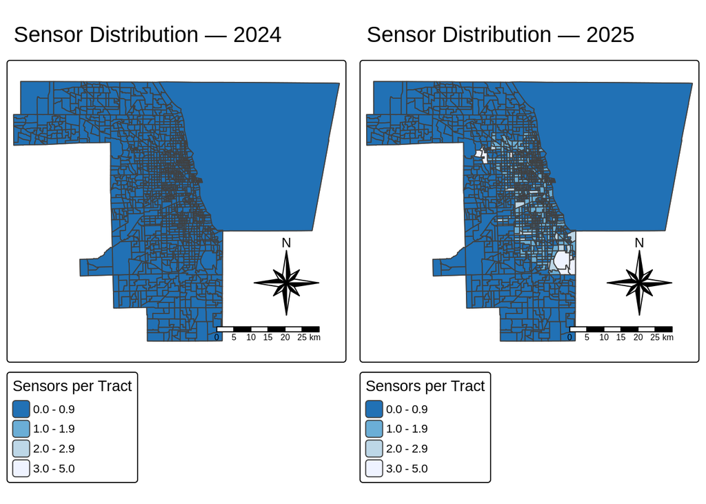

```r
#Note: This displays maps side-by-side
tmap_arrange(map_plot_2024, map_plot_2025, ncol = 2)
```

## **1) Summmary of the Chicago Distribution Map**

Some neighborhoods have multiple sensors within the same tract, while others have none at all. This uneven coverage matters because it affects how well we can understand pollution levels in different communities. Areas with more sensors get more detailed and reliable air‑quality data, while neighborhoods with fewer sensors may have gaps in monitoring.

Comparing the two years side by side also helps show whether the network expanded or shifted. If certain tracts gained sensors in 2025, it could mean the monitoring program is trying to fill coverage gaps. If other areas stayed empty both years, that might point to neighborhoods that are still being overlooked. Overall, the map helps highlight potential inequalities in environmental monitoring and sets the stage for analyzing whether those same areas also experience higher pollution levels.

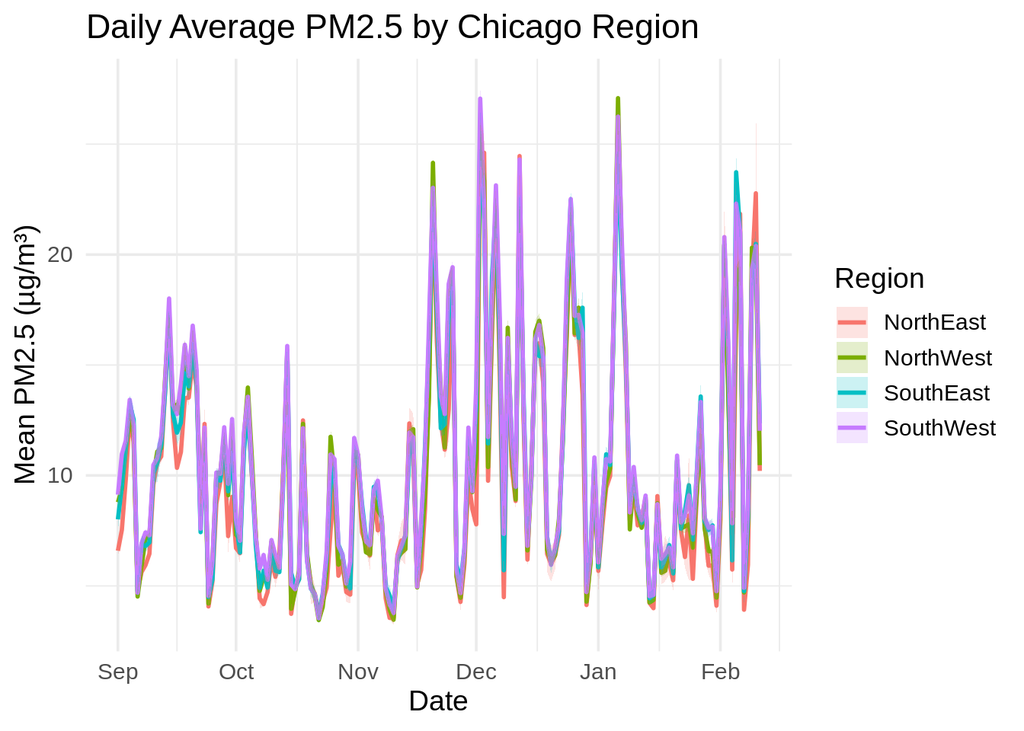

```r
#Note: Daily averages + confidence intervals by region
daily_region_avg <- filtered_data %>%
  group_by(date, region) %>%
  summarise(
    mean_pm25 = mean(pm25_mass, na.rm = TRUE),
    sd_pm25 = sd(pm25_mass, na.rm = TRUE),
    n = n(),
    se = sd_pm25 / sqrt(n),
    lower = mean_pm25 - 1.96 * se,
    upper = mean_pm25 + 1.96 * se,
    .groups = "drop"
  )

# Plot: PM2.5 trends with confidence intervals
ggplot(daily_region_avg, aes(x = date, y = mean_pm25, color = region)) +
  geom_line(size = 1) +
  geom_ribbon(aes(ymin = lower, ymax = upper, fill = region),
              alpha = 0.2, color = NA) +
  theme_minimal(base_size = 14) +
  labs(
    title = "Daily Average PM2.5 by Chicago Region",
    x = "Date",
    y = "Mean PM2.5 (µg/m³)",
    color = "Region",
    fill = "Region"
  )
```

## **1)Summary of Daily PM2.5 Levels Over Time**

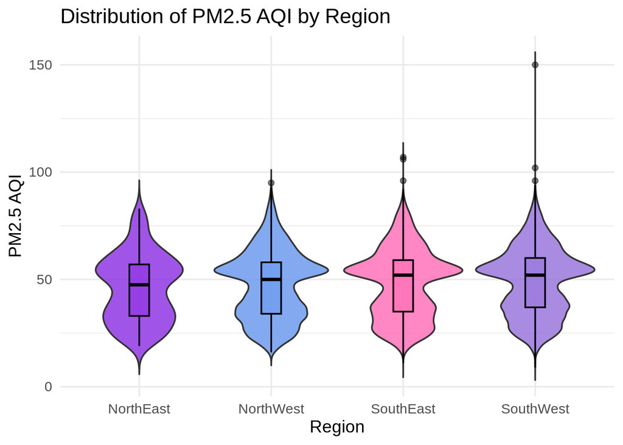

```r
#Note: Violin plot comparing AQI distributions across regions
#Note: colors i will be using to differentiate between regions
my_colors <- c(
  "NorthEast" = "#8A2BE2",   # purple
  "NorthWest" = "#6495ED",   # cornflower blue
  "SouthEast" = "#FF69B4",   # hot pink
  "SouthWest" = "#9370DB"    # medium purple
)

ggplot(filtered_data, aes(x = region, y = pm25_aqi, fill = region)) +
#Note: Smooth distribution shape
  geom_violin(trim = FALSE, alpha = 0.8) +
#Note: Added median + IQR
  geom_boxplot(width = 0.15, color = "black", alpha = 0.5) +
#Note: Used purple-blue-pink palette
  scale_fill_manual(values = my_colors) +
  theme_minimal(base_size = 14) +
  labs(
    title = "Distribution of PM2.5 AQI by Region",
    x = "Region",
    y = "PM2.5 AQI"
  ) +
  theme(legend.position = "none")
```

## **2)Summary: Violin Plot PM2.5 AQI by Region**

This violin plot compares the distribution of PM2.5 AQI values across the four Chicago regions (NorthEast, NorthWest, SouthEast, SouthWest). Some regions show wider or higher‑shifted distributions, meaning they experience more frequent or more intense pollution days such as the Southwest Region. This highlights that air‑quality conditions are not evenly shared across the city and that certain regions may face greater health risks.

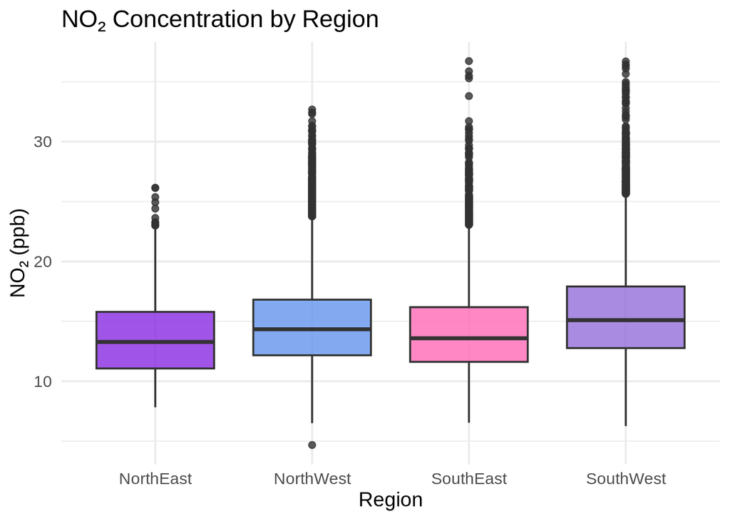

```r
#Note: Boxplot concentration by region
#Note: Code chunk is demontrating median + spread
ggplot(filtered_data, aes(x = region, y = no2, fill = region)) +
  geom_boxplot(alpha = 0.8) +
  scale_fill_manual(values = my_colors) +
  theme_minimal(base_size = 14) +
  labs(
    title = "NO₂ Concentration by Region",
    x = "Region",
    y = "NO₂ (ppb)"
  ) +
  theme(legend.position = "none")
```

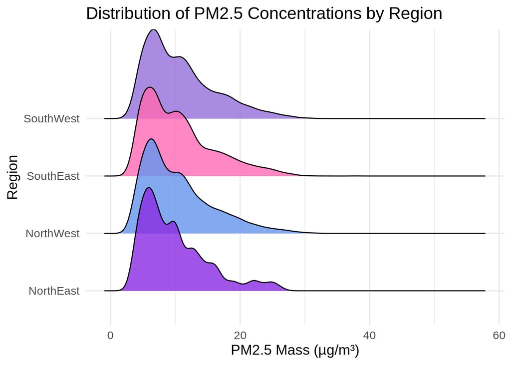

```r
#Note: Ridgeline plot by region
#Note: Installed ggridges in console
library(ggridges)
#Note: Code chunk explains smooth density curves stacked vertically
ggplot(filtered_data, aes(x = pm25_mass, y = region, fill = region)) +
  geom_density_ridges(alpha = 0.8) +
  scale_fill_manual(values = my_colors) +
  theme_minimal(base_size = 14) +
  labs(
    title = "Distribution of PM2.5 Concentrations by Region",
    x = "PM2.5 Mass (µg/m³)",
    y = "Region"
  ) +
  theme(legend.position = "none")
```

## **4)Summary: PM2.5 by Region Ridgeline Plot**

This ridgeline plot shows the shape of PM2.5 distributions for each region. Regions with curves shifted toward higher values experience more frequent high‑pollution days. This helps identify which parts of the city face chronic exposure rather than occasional spikes.

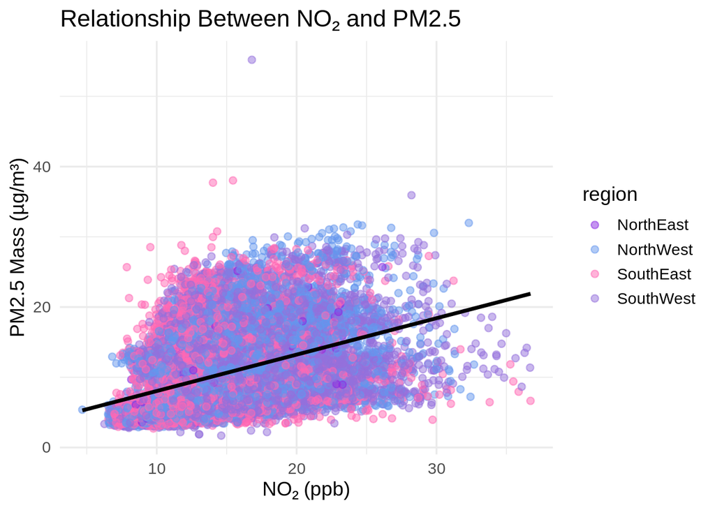

```r
#Note: Scatterplot of PM2.5 mass vs. NO2
ggplot(filtered_data, aes(x = no2, y = pm25_mass, color = region)) +
  geom_point(alpha = 0.5, size = 2) +
#Note: included trend line
  geom_smooth(method = "lm", se = FALSE, color = "black") +
  scale_color_manual(values = my_colors) +
  theme_minimal(base_size = 14) +
  labs(
    title = "Relationship Between NO₂ and PM2.5",
    x = "NO₂ (ppb)",
    y = "PM2.5 Mass (µg/m³)"
  )
```

## **5)Summary: Scatterplot of PM2.5 Mass vs. No2**

The scatterplot compares PM2.5 and NO₂ levels to see whether they rise together. A positive relationship suggests that traffic or combustion‑related sources may be contributing to PM2.5 levels. This helps explain why some regions with higher NO₂ also show higher PM2.5.

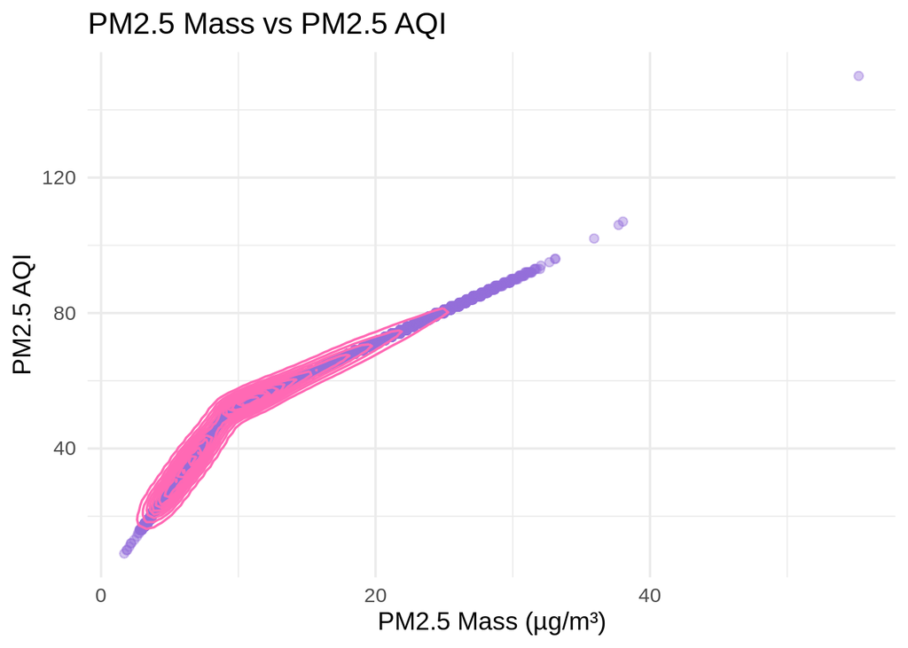

```r
#Note: PM2.5 mass vs PM2.5 aqi
ggplot(filtered_data, aes(x = pm25_mass, y = pm25_aqi)) +
#Note: Purple scatter points
   geom_point(alpha = 0.4, color = "#9370DB") +
#Note: Pink density contours
  geom_density2d(color = "#FF69B4") +
  theme_minimal(base_size = 14) +
  labs(
    title = "PM2.5 Mass vs PM2.5 AQI",
    x = "PM2.5 Mass (µg/m³)",
    y = "PM2.5 AQI"
  )
```

## **6)Summary: Scatterplot of PM2.5 Mass vs. PM2.5 AQI**

This plot analyzes whether PM2.5 mass concentrations align with their corresponding AQI values. The upward trend confirms that AQI is behaving as expected and can be trusted as a measure of health‑related air‑quality conditions.

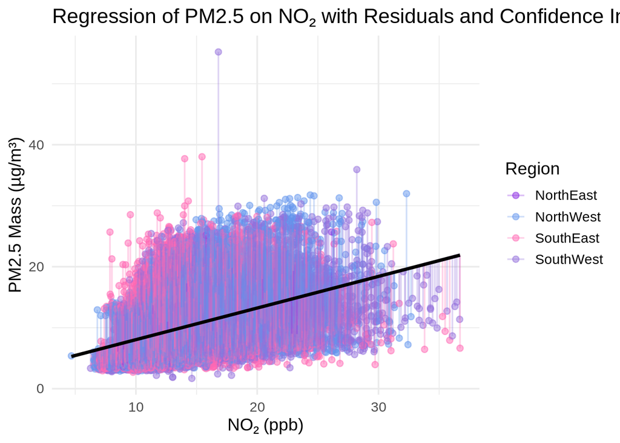

```r
#Note: Fitting a regression line model
#Note: Model predicting PM2.5 mass from NO2
model_pm25_no2 <- lm(pm25_mass ~ no2, data = filtered_data)

#Note: Creating a dataset that matches the model's rows exactly to avoid the length mismatch error.
model_data <- filtered_data %>%
#Note: keeps only rows used in the model
  drop_na(pm25_mass, no2) %>%
  mutate(
#Note: predicted only PM2.5
    fitted = fitted(model_pm25_no2),
    residuals = resid(model_pm25_no2)
  )
#Note: Plotting regression line + CI + residuals
ggplot(model_data, aes(x = no2, y = pm25_mass, color = region)) +
#Note: Raw data points
  geom_point(alpha = 0.5, size = 2) +
#Note: Residual lines (vertical)
  geom_segment(aes(xend = no2, yend = fitted), alpha = 0.3) +
#Note: Regression line with 95% CI
  geom_smooth(method = "lm", se = TRUE, color = "black", fill = "#9370DB", alpha = 0.3) +

  scale_color_manual(values = my_colors) +

  theme_minimal(base_size = 14) +
  labs(
    title = "Regression of PM2.5 on NO₂ with Residuals and Confidence Intervals",
    x = "NO₂ (ppb)",
    y = "PM2.5 Mass (µg/m³)",
    color = "Region"
  )
```

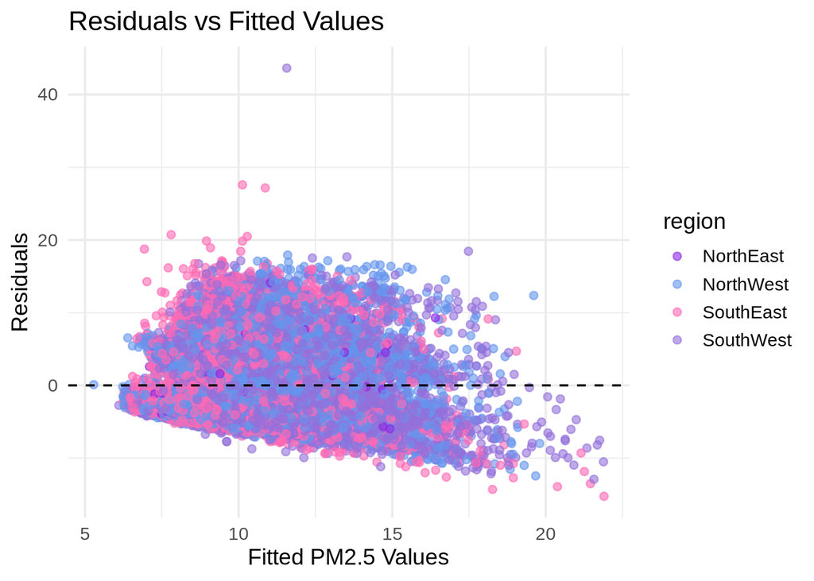

```r
#Note: Residuals vs Fitted diagnostic plot
ggplot(model_data, aes(x = fitted, y = residuals, color = region)) +
  geom_point(alpha = 0.6) +
  geom_hline(yintercept = 0, linetype = "dashed", color = "black") +
  scale_color_manual(values = my_colors) +
  theme_minimal(base_size = 14) +
  labs(
    title = "Residuals vs Fitted Values",
    x = "Fitted PM2.5 Values",
    y = "Residuals"
  )
```

## **7)Summary:**

This regression line examines how strongly NO₂ predicts PM2.5 levels across Chicago. The regression plot shows a semi-clear upward trend, meaning that higher NO₂ concentrations are associated with higher PM2.5 mass across all four regions.

This suggests that certain neighborhoods may have additional pollution sources beyond NO₂ alone. The residuals‑vs‑fitted plot further shows that the model fits some ranges of PM2.5 better than others, further supporting the idea that air‑quality conditions vary across area. Overall, this analysis supports the broader finding that pollution exposure in Chicago is uneven and influenced by both traffic emissions and regional environmental factors.

## **Conclusion**

# *Final Takeaways*

Throughout this project, I encountered several challenges that pushed me to think more critically about data analysis and problem‑solving. One of the biggest obstacles was dealing with repeated R Markdown errors that prevented me from saving or continuing my work in the same file. Because of this, I had to create multiple new files and reorganize my workflow just to keep moving forward. Although frustrating at times, it taught me how important it is to adapt quickly and stay flexible when technical issues get in the way.

Filtering and preparing the dataset also became more complicated than I expected. With so many variables and missing values, I had to be strategic about how I cleaned the data and which variables I kept. This process helped me understand how much thought goes into building a dataset that actually supports a research question. Developing the plots required even more planning, since each visualization needed to clearly connect back to the idea of spatial and temporal inequality in Chicago’s air quality.

Overall, this project turned into a valuable learning experience. It pushed me to troubleshoot problems, rethink my approach when things didn’t work, and make intentional decisions about how to analyze and present data. More than anything, it showed me how data science involves both technical skills and creative problem‑solving, and it helped me grow more confident in navigating both.